# Lógica y Pensamiento Científico

Falacias Informales 1

Bogdan G. Popescu

bgpopescu@tec.mx

Tecnologico de Monterrey

# Bienvenidos

## Objetivos de aprendizaje

### Panorama

1. **Nombrar** la falacia informal identificando el movimiento descompuesto.
2. Separar una falacia de una **pregunta legítima** sobre evidencia, fuente o emoción.
3. Evitar la **falacia de la falacia**: decir qué evidencia *sí* decidiría la conclusión.

## Repaso

| Pregunta | Respuesta de la sesión anterior |
| --- | --- |
| ¿Forma válida vs. conclusión cierta? | Una forma válida puede cargar una afirmación falsa |
| ¿Las gemelas **formales**? | Cuatro trampas, cada una imitando una forma válida (+ una herramienta suelta) |
| ¿El bat y la pelota? | La respuesta sentida ($0.10) no era la respuesta revisada ($0.05) |

Los trucos formales rompen la **forma**.  
Hoy: trucos que rompen el **contenido**

# Acto II: Las falacias informales

## Formal vs. informal

|  | Dónde se ve la falla |
| --- | --- |
| **Falacia formal** | solo en la **forma** del argumento — no hace falta el contenido |
| **Falacia informal** | solo en el **contenido**: relevancia, ambigüedad, evidencia, contexto |

Un argumento falaz puede tener una **conclusión cierta** — e incluso ser **formalmente válido**.

Casi ninguna falacia es mentira: razonamiento descuidado o motivado, no engaño consciente.

## El diagnóstico en tres pasos

Caso de demostración:

> “La delincuencia bajó después del toque de queda. El toque de queda funciona.”
1. **Nombra el movimiento** → falsa causa.
2. **Cita las palabras exactas** → “bajó *después*” se vuelve “*funciona*.”
3. **Di qué lo decidiría** → ¿podría haber otras causas detrás de la caída?

## El mapa: cuatro familias

*Doce trucos informales, con color por familia — más una táctica de volumen.*

Razonamiento defectuosoFuentes mal usadasAfirmaciones distorsionadasApelaciones emocionales

1falsa causa

2razonamiento circular

3ad hominem

4apelación a la autoridad

5hombre de paja

6pista falsa

7pendiente resbaladiza

8equivocación

9falso dilema

10apelación al miedo

11apelación a la lástima

12efecto arrastre

∞**Gish Gallop**la táctica de volumen — carga cualquier movimiento de arriba; ya lo sintieron*meta*

## El mapa: cuatro familias

*Doce trucos informales, con color por familia — más una táctica de volumen.*

Razonamiento defectuosoFuentes mal usadasAfirmaciones distorsionadasApelaciones emocionales

1falsa causa

2razonamiento circular

3ad hominem

4apelación a la autoridad

5hombre de paja

6pista falsa

7pendiente resbaladiza

8equivocación

9falso dilema

10apelación al miedo

11apelación a la lástima

12efecto arrastre

∞**Gish Gallop**la táctica de volumen — regresa en una sesión futura*meta*

## Falsa causa

> “La delincuencia bajó después del toque de queda. El toque de queda funciona.”
- *Post hoc ergo propter hoc*:
  - después de esto, por lo tanto a causa de esto.
- Recuerden: la “cura” de la vitamina C.
- Rivales posibles:
  - tendencias previas
  - coincidencia
  - políticas simultáneas
  - selección

## “Ni un oso a la vista” — falsa causa

[video not shown]

- **Apliquen los tres pasos a Homero**
- La roca de Lisa *es* el método del contraejemplo.

## La roca no prueba nada

|  | La patrulla de Homero | La roca de Lisa |
| --- | --- | --- |
| **Afirmación** | La patrulla mantiene lejos a los osos. | La roca mantiene lejos a los tigres. |
| **Evidencia** | No hay osos a la vista. | No hay tigres a la vista. |
| **Lógica** | Está aquí y ellos no → funciona. | *Exactamente igual.* |

- “No pasó nada después de X” no muestra que **X lo haya impedido**.
- Nunca hubo osos por aquí
  - la patrulla se lleva el crédito por **nada**.
- La roca de Lisa: el mismo argumento, conclusión absurda → el **argumento** está roto.

## La roca no prueba nada

|  | La patrulla de Homero | La roca de Lisa |
| --- | --- | --- |
| **Afirmación** | La patrulla mantiene lejos a los osos. | La roca mantiene lejos a los tigres. |
| **Evidencia** | No hay osos a la vista. | No hay tigres a la vista. |
| **Lógica** | Está aquí y ellos no → funciona. | *Exactamente igual.* |

**Eso es falsa causa:** “no hay osos después” no muestra por sí solo que la patrulla los mantenga lejos.

## Razonamiento circular

> “Fumar es dañino para la salud — porque daña tu salud.”
- La razón no da ningún apoyo independiente
  - para aceptarla, ya tienes que aceptar la afirmación.
- Aquí la razón nada más **reformula la afirmación**

**La prueba:** ¿la razón se sostiene sola, sin creer ya la conclusión?

**Su turno:** “Este curso es a prueba de futuro — porque las habilidades que enseña no van a quedar obsoletas.”

## “Tiene electrolitos” — Idiocracy (2006)

[video not shown]

- **Apliquen los tres pasos**:
- fíjense en que la razón y la afirmación son la misma oración.

## Lo que las plantas necesitan

|  | El argumento de Brawndo *(la película)* | Una razón de verdad |
| --- | --- | --- |
| **¿Por qué usarlo?** | “Tiene electrolitos.” | “Las parcelas con Brawndo rinden más que con agua.” |
| **¿De dónde sale la razón?** | “electrolitos” = “lo que las plantas necesitan” = **la afirmación** | una prueba independiente |
| **El movimiento** | razonamiento circular | un argumento verificable |

- Cuatro vueltas, cero datos nuevos: cada “razón” solo renombra la afirmación.

**Prueba:** ¿la razón les da algo que puedan verificar **sin aceptar ya la afirmación**?

## “Es un encubrimiento” — razonamiento circular, en la vida real

> “No hay pruebas porque está todo encubierto —  
> y sabemos que está encubierto porque no hay pruebas.”
- Aquí no hay reformulación: **dos afirmaciones distintas**, cada una defendida por la otra.
- Se sella sola: nada podría jamás contar en contra.

## Recta vs. circular

**Recta** — la razón se sostiene sola:

- Fumar es dañino — lo muestran los estudios de cohorte.
- Verificable.

**Circular** — la razón solo lo reformula:

- Fumar es dañino — porque daña tu salud.

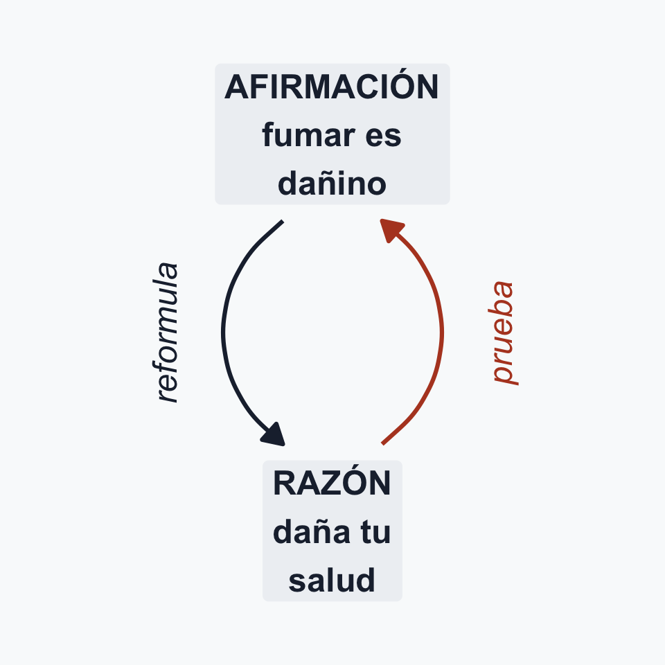

**Tautología vs. razonamiento circular** — una tautología es un *enunciado* vacío (“es lo que es”); el razonamiento circular es un *argumento* cuyo apoyo regresa en bucle a su conclusión. Algunos círculos se apoyan en una tautología — pero los conceptos son distintos.

## Cierta, pero vacía

> “O llueve mañana, o no llueve.”
- **Siempre cierta** — no hay manera de que se equivoque.
- Y no les dice **nada**
- Eso es una **tautología:** cierta porque no dice nada sobre el mundo.

**Lugares comunes** — las versiones de todos los días:

- “Los niños son niños.”
- “Una regla es una regla.”

## Ad hominem

> “Las cifras del alcalde muestran que el toque de queda bajó la delincuencia. El tipo es un ratero. Ignórenlo.”
- Solo se golpea a quien argumenta
  - las cifras se quedan sin respuesta.
- Aunque *“es un ratero”* sea cierto, eso no vuelve falsas las cifras.

## “Esto es insulto” — por fin con nombre

[video not shown]

El cuarto que el sketch archiva como *insulto* también tiene nuestro nombre: **ataca a la persona, y el argumento nunca ocurre.**

## Cuartos distintos

|  | El cuarto de Barnard | “Ignoren las cifras del alcalde” |
| --- | --- | --- |
| **¿Ataca a la persona?** | Sí — con puros insultos | Sí — sus motivos |
| **¿Hay un argumento?** | No — nunca se ofreció ninguno | Sí — las cifras de delincuencia |
| **El movimiento** | Puro **insulto** | **Ad hominem** — el ataque *desecha* el argumento |

- La clínica archiva insulto y argumento en **cuartos separados**.
- La falacia empieza cuando el ataque **sustituye la respuesta** a un argumento real.

**Prueba:** ¿había un argumento — y atacar a la persona lo hizo *desaparecer*?

## Etiquetas, no respuestas

> “Deberíamos restringir la migración.” — “¡Eso es racista!”  
> “Deberíamos ampliar los apoyos sociales.” — “¡Eso es comunismo!”
- La etiqueta sustituye la respuesta.
- “¡Woke!” · “¡Fascista!” · “¡Negacionista!” · “¡Fake news!”
- La etiqueta hasta podría quedar — el argumento sigue sin respuesta.
- La señal: la conversación se acaba en cuanto se aplica la etiqueta.

## Cuándo sí es justo

[output not shown]

Regla: cuestionar una fuente puede reducir el peso del testimonio

No muestra por sí solo que la conclusión sea falsa.

Para responderle a la conclusión:

- entra a las razones
- a la evidencia
- al enlace inferencial.

## Apelación a la autoridad

> “El jefe de policía dice que el toque de queda funciona. **Caso cerrado.**”
- La falacia: el estatus sustituye a la evidencia
- Otro ejemplo: un premio Nobel de física opinando sobre medicina (campo equivocado)
- **Legítimo**: citar el consenso experto, en su campo, con la evidencia disponible.
- Ojo con las apelaciones vagas: “los estudios muestran”, “los expertos coinciden”
  - ¿*cuáles* estudios?
  - ¿*cuáles* expertos?

## “¿Qué cigarro fuma usted, doctor?” (1949)

[video not shown]

Un anuncio real, al aire por una década. **¿Qué está haciendo exactamente la bata del doctor en este argumento?**

## La bata blanca

|  | Lo que muestra el anuncio | Lo que prueba |
| --- | --- | --- |
| **La autoridad** | Médicos — “de todas las ramas” | El campo correcto para afirmaciones de *salud*… |
| **Lo que se midió** | Qué marca *fuman* los médicos | …pero nunca se hace una afirmación de salud |
| **La encuesta** | “Repetida, nacional” — real | A los médicos les regalaron **cartones de Camel** y luego les preguntaron su marca |

- La bata agrega confianza; el anuncio nunca da evidencia.
- Una encuesta real puede medir algo que no importa.
- La conclusión no dicha (*es seguro fumar*) nunca se puso a prueba.
- **Prueba:** ¿la autoridad está dando evidencia?

## Ejercicio — nombra el movimiento

En parejas. ¿Cuál de los cuatro movimientos de hoy — si es que alguno?

1. “Empecé a tomar vitamina C en marzo. No me he enfermado desde entonces. Funciona.”
2. “No le hagan caso a su argumento de economía — se ha divorciado dos veces.”
3. “Esta app es la mejor, porque ninguna otra app es tan buena.”
4. “Un actor famoso dice que esta dieta cura las alergias. Con eso me basta.”
5. “La delincuencia subió el año en que entró el nuevo alcalde. Él la causó.”
6. “La ingeniera revisó el puente, encontró grietas profundas y dice que no lo crucen.”

## Respuestas

| # | La afirmación | El movimiento |
| --- | --- | --- |
| **1** | vitamina C en marzo, sin enfermarse desde entonces | **falsa causa** |
| **2** | ignoren su economía — se divorció dos veces | **ad hominem** |
| **3** | la mejor, porque ninguna otra es tan buena | **razonamiento circular** |
| **4** | un actor famoso sobre las alergias | **apelación a la autoridad** |
| **5** | subió la delincuencia, luego el alcalde la causó | **falsa causa** |
| **6** | la ingeniera halló grietas — no crucen | **no es falacia** |

- **El 1 y el 5 son el mismo movimiento** — uno para elogiar, otro para culpar.
- **El 6 es legítimo**: el campo correcto y evidencia que podrías ir a verificar.

## Conclusión

Nombra el movimiento, cita las palabras, di qué lo decidiría.

- **Razonamiento defectuoso**
  - falsa causa (después ≠ por causa de)
  - razonamiento circular (sin apoyo independiente — el bucle regresa a la afirmación)
    - a menudo vía tautologías y lugares comunes: ciertos porque no dicen nada; no prueban nada.
- **Fuentes mal usadas**
  - ad hominem
  - apelación a la autoridad